## Determination of white wine quality by exploratory data analysis and multiple linear regression model using R

### By Lasantha Rathnayake

In this exploratory data analysis study, white wine Quality data is examined.

The dataset used in this investigation is a part of two datasets (for white wine and red whine) from the following is the source.

- P. Cortez, A. Cerdeira, F. Almeida, T. Matos and J. Reis. Modeling wine preferences by data mining from physicochemical properties. In Decision Support Systems, Elsevier, 47(4):547-553. ISSN: 0167-9236.

### Information about dataset

In the dataset, there are about 4900 records and 12 attributes. Most of the attributes are chemical and physical properties. The data were obtained experimentally for different wine types.

The dataset contains following attributes.

```
##  [1] "X"                    "fixed.acidity"        "volatile.acidity"
##  [4] "citric.acid"          "residual.sugar"       "chlorides"
##  [7] "free.sulfur.dioxide"  "total.sulfur.dioxide" "density"
## [10] "pH"                   "sulphates"            "alcohol"
## [13] "quality"
```

The size of the dataset is as follows.

```
## [1] 4898   12
```

In the original source, followings are the descriptions of attributes in the dataset.The corresponding units if any for the attributes are also given in along with the attribute name.

fixed acidity (g/dm^3):

- Most acids involved with wine or fixed or nonvolatile (do not evaporate readily).

volatile acidity (g/dm^3):

- The amount of acetic acid in wine, which at too high of levels can lead to an unpleasant, vinegar taste

citric acid (g/dm^3):

- Found in small quantities, citric acid can add ‘freshness’ and flavor to wines

residual sugar (g/dm^3):

- The amount of sugar remaining after fermentation stops, it’s rare to find wines with less than 1 gram/liter and wines with greater than 45 grams/liter are considered sweet

chlorides (g/dm^3):

- The amount of salt in the wine

free sulfur dioxide (g/dm^3):

- The free form of SO2 exists in equilibrium between molecular SO2 (as a dissolved gas) and bisulfite ion; it prevents microbial growth and the oxidation of wine

total sulfur dioxide (g/dm^3):

- Amount of free and bound forms of S02; in low concentrations, SO2 is mostly undetectable in wine, but at free SO2 concentrations over 50 ppm, SO2 becomes evident in the nose and taste of wine

density (g/cm^3):

- The density of water is close to that of water depending on the percent alcohol and sugar content

pH: * Describes how acidic or basic a wine is on a scale from 0 (very acidic) to 14 (very basic); most wines are between 3-4 on the pH scale

sulfates (g/dm^3):

- A wine additive which can contribute to sulfur dioxide gas (S02) levels, which acts as an antimicrobial and antioxidant

alcohol (% by volume):

- The percent alcohol content of the wine

quality:

- Score between 0 and 10

In order to get a general idea of the data, the following snippet of data was obtained (only the first six records of the dataset).

```
##   fixed.acidity volatile.acidity citric.acid residual.sugar chlorides
## 1           7.0             0.27        0.36           20.7     0.045
## 2           6.3             0.30        0.34            1.6     0.049
## 3           8.1             0.28        0.40            6.9     0.050
## 4           7.2             0.23        0.32            8.5     0.058
## 5           7.2             0.23        0.32            8.5     0.058
## 6           8.1             0.28        0.40            6.9     0.050
##   free.sulfur.dioxide total.sulfur.dioxide density   pH sulphates alcohol
## 1                  45                  170  1.0010 3.00      0.45     8.8
## 2                  14                  132  0.9940 3.30      0.49     9.5
## 3                  30                   97  0.9951 3.26      0.44    10.1
## 4                  47                  186  0.9956 3.19      0.40     9.9
## 5                  47                  186  0.9956 3.19      0.40     9.9
## 6                  30                   97  0.9951 3.26      0.44    10.1
##   quality
## 1       6
## 2       6
## 3       6
## 4       6
## 5       6
## 6       6
```

All the attributes in the dataset are numerical. However, The ‘quality’ attribute was factorized, because the it is used to rank the wine quality.

### Univariate Plots Selection and analysis

Lets look at the distribution of each individual variable as histograms. For each variable, a summary of the data distribution is given below the plot.

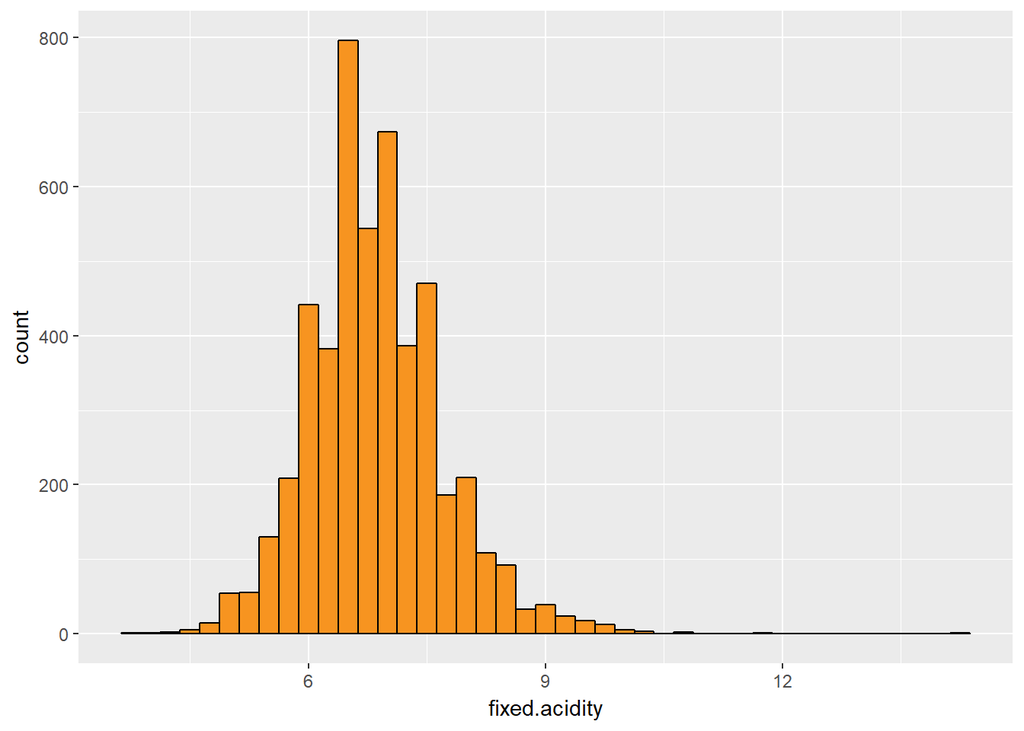

The data in the fixed.acidity variable is normally distributed with following statistics.

```
##    Min. 1st Qu.  Median    Mean 3rd Qu.    Max.
##   3.800   6.300   6.800   6.855   7.300  14.200
```

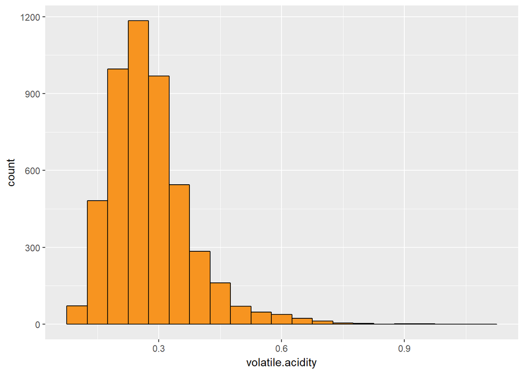

The data in the volatile.acidity variable is normally distributed with following statistics.

```
##    Min. 1st Qu.  Median    Mean 3rd Qu.    Max.
##  0.0800  0.2100  0.2600  0.2782  0.3200  1.1000
```

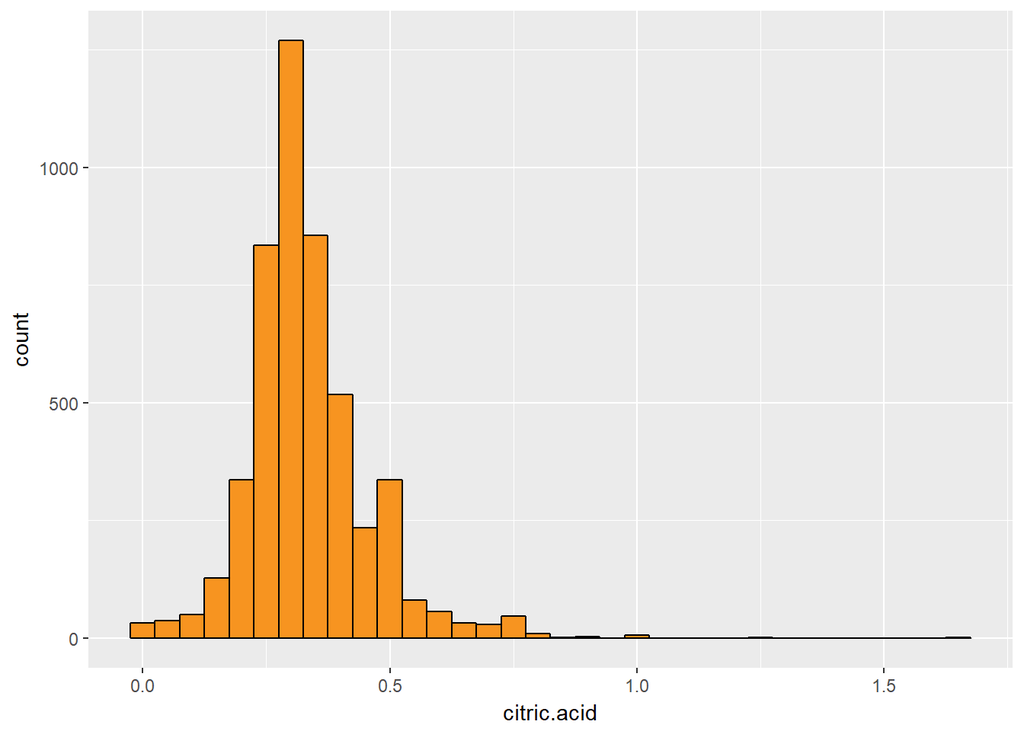

The data in the citric.acid variable is normally distributed with following statistics.

```
##    Min. 1st Qu.  Median    Mean 3rd Qu.    Max.
##  0.0000  0.2700  0.3200  0.3342  0.3900  1.6600
```

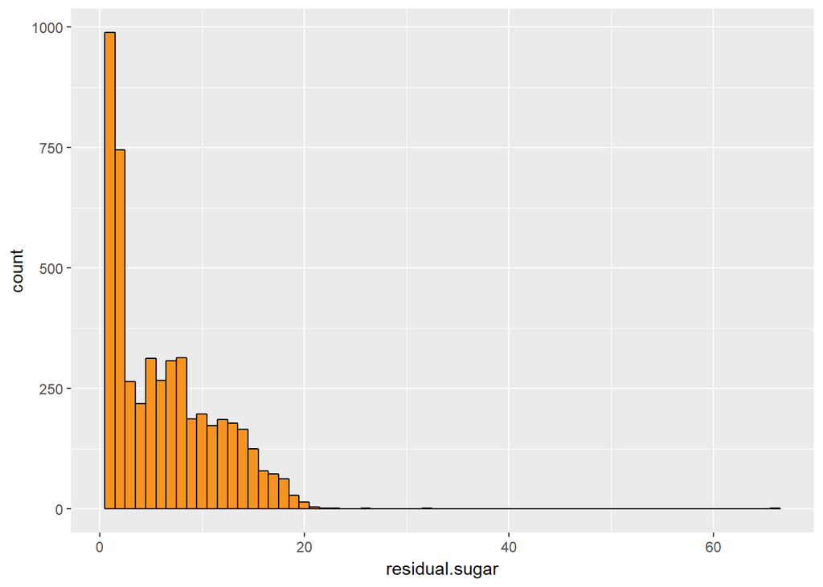

```
##    Min. 1st Qu.  Median    Mean 3rd Qu.    Max.
##   0.600   1.700   5.200   6.391   9.900  65.800
```

When comparing the maximum value residual.sugar content with 3rd quartile, there is a huge different can be observable. This is probably due to outliers. In the following, plot the outliers were removed.

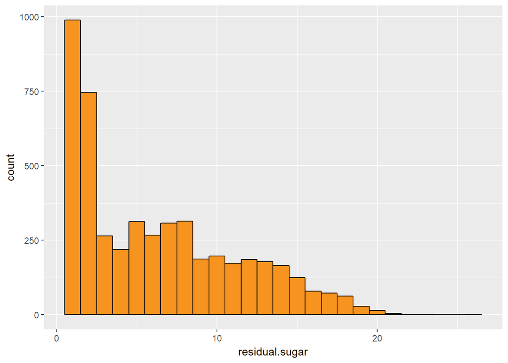

After removing the outliers, following is the summary for residual.sugar variable. Th removal of outliers give much better visualization for the data distribution.

```
##    Min. 1st Qu.  Median    Mean 3rd Qu.    Max.
##   0.600   1.700   5.200   6.369   9.900  26.050
```

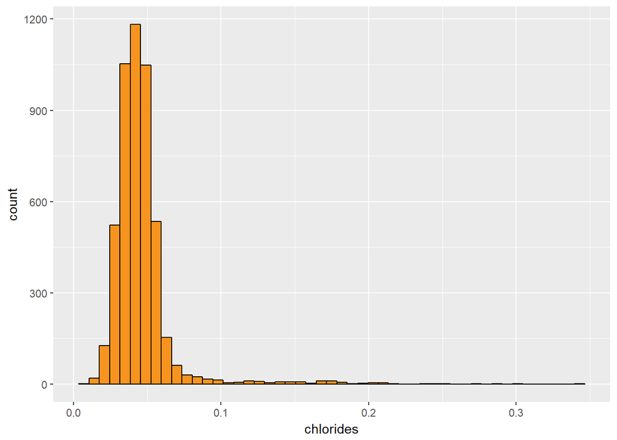

The data in the chlorides variable is normally distributed with following statistics. The extreme values of chlorides are difficult to determine without further information.

```
##    Min. 1st Qu.  Median    Mean 3rd Qu.    Max.
## 0.00900 0.03600 0.04300 0.04577 0.05000 0.34600
```

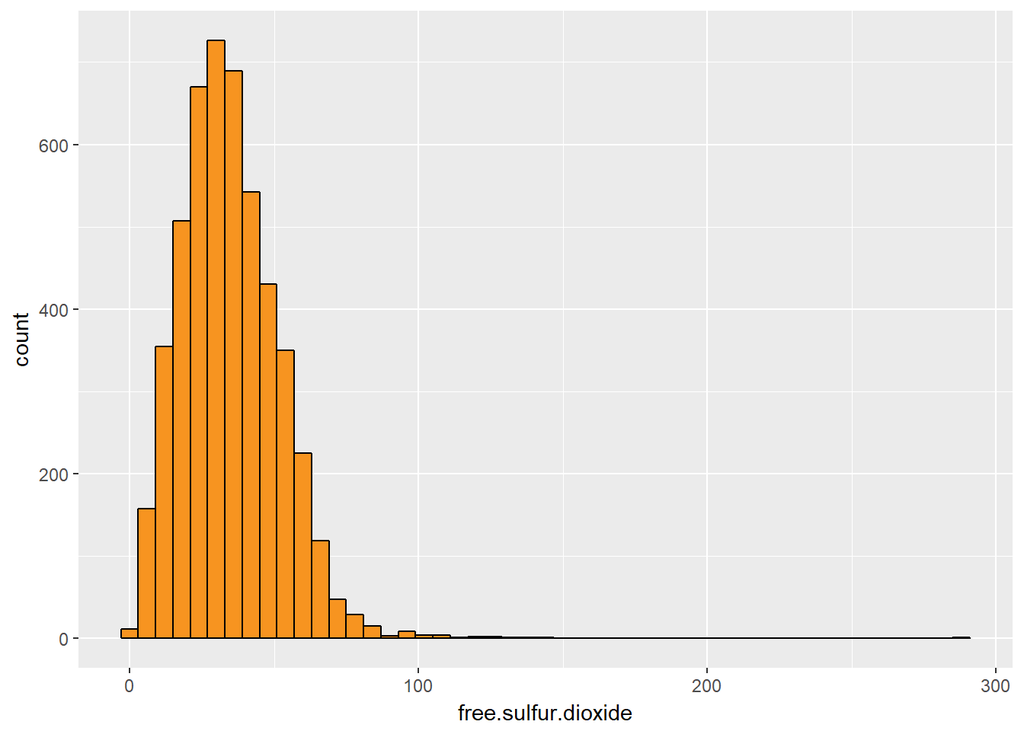

The data in the free.sulfur.dioxide variable is normally distributed with following statistics.

```
##    Min. 1st Qu.  Median    Mean 3rd Qu.    Max.
##    2.00   23.00   34.00   35.31   46.00  289.00
```

In free.sulfur.dioxide also there are some potential outliers when compare maximum value with the third quartile. Therefore, the extreme values should be removed.

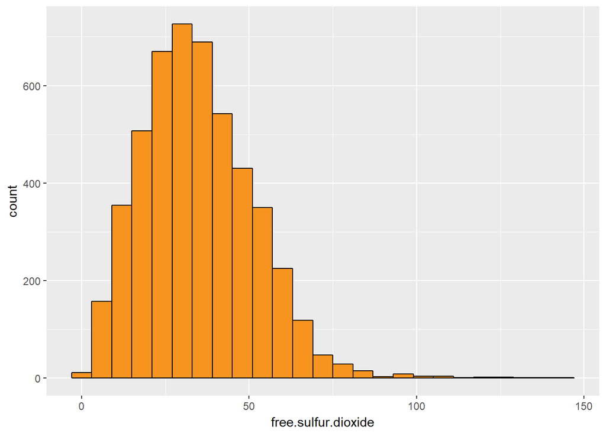

After removing extreme values of free.sulfur.dioxide, following summary statistics can be observable.

```
##    Min. 1st Qu.  Median    Mean 3rd Qu.    Max.
##    2.00   23.00   34.00   35.26   46.00  146.50
```

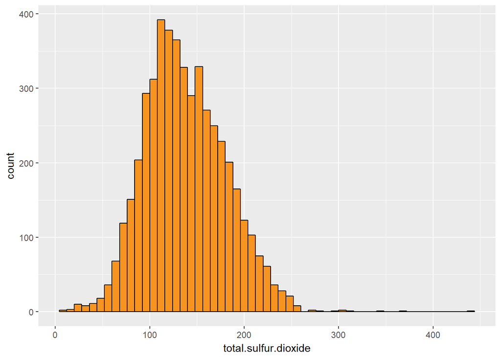

The data in the total.sulfur.dioxide variable is normally distributed with following statistics.

```
##    Min. 1st Qu.  Median    Mean 3rd Qu.    Max.
##     9.0   108.0   134.0   138.4   167.0   440.0
```

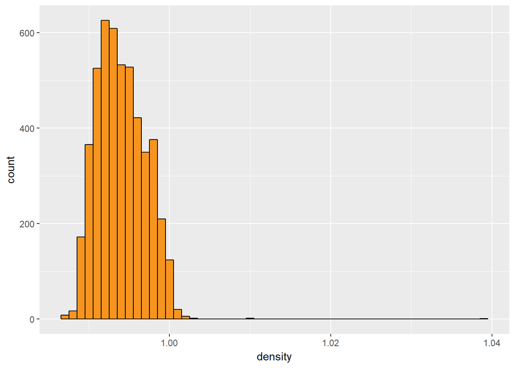

The data in the density variable is normally distributed with following statistics.

```
##    Min. 1st Qu.  Median    Mean 3rd Qu.    Max.
##  0.9871  0.9917  0.9937  0.9940  0.9961  1.0390
```

Generally, in standard conditions, the density of water is 1.00 g/cm^3. Therefore, the density of a solution in which the water is the solvent, should be slightly less than 1.00 g/cm^3. In the above plot we can observe at least two density values greater than 1.00 g/cm^3. Therefore, we can remove those outliers from the dataset to clean the dataset. Following plot was generated without the density outliers.

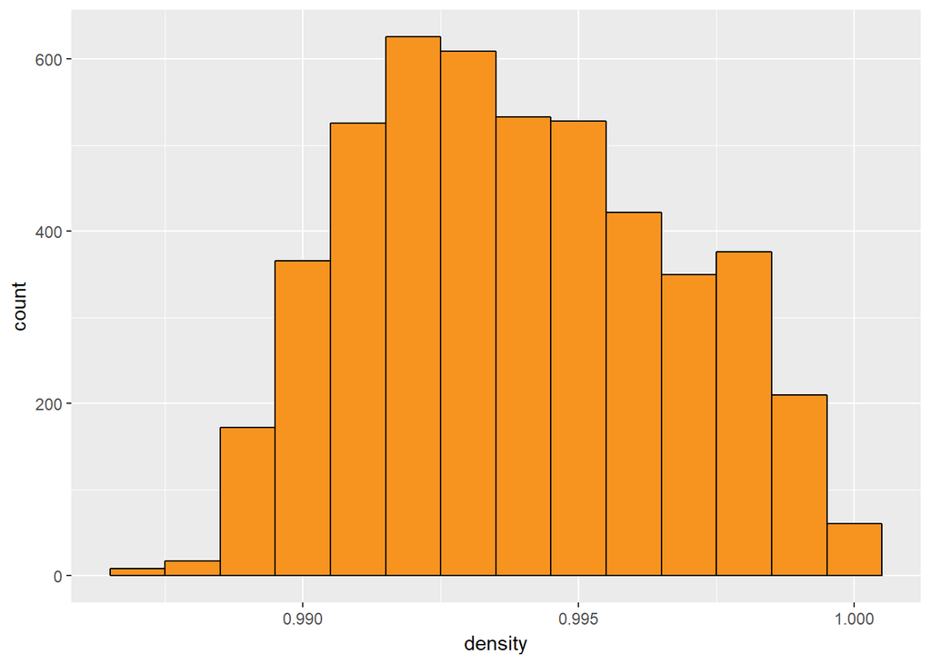

After removing extreme values of density variable, following summary statistics can be observable.

[output not shown]

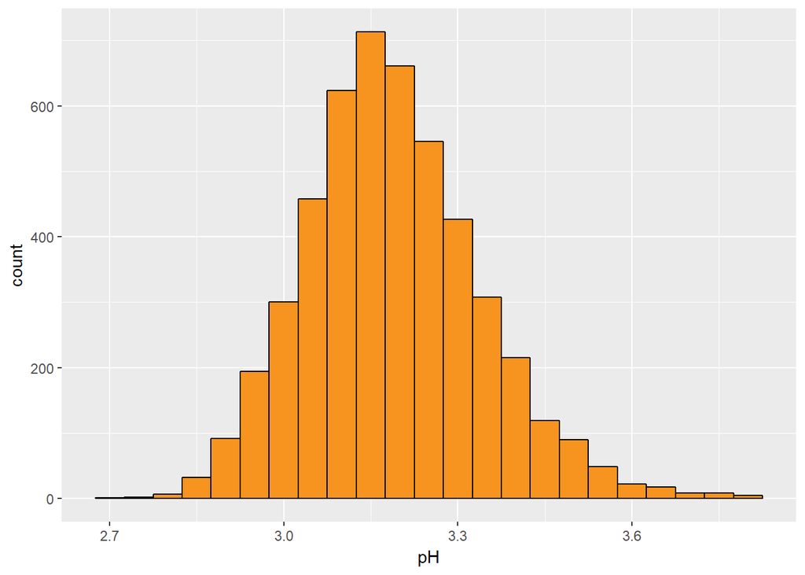

The data in the pH variable is normally distributed with following statistics. Compare to other variables, the pH values show better Gaussian distribution.

```
##    Min. 1st Qu.  Median    Mean 3rd Qu.    Max.
##   2.720   3.090   3.180   3.188   3.280   3.820
```

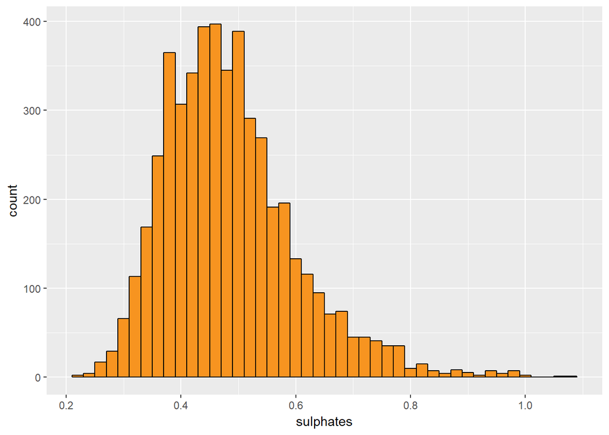

The data in the sulfates variable is normally distributed with following statistics.

```
##    Min. 1st Qu.  Median    Mean 3rd Qu.    Max.
##  0.2200  0.4100  0.4700  0.4898  0.5500  1.0800
```

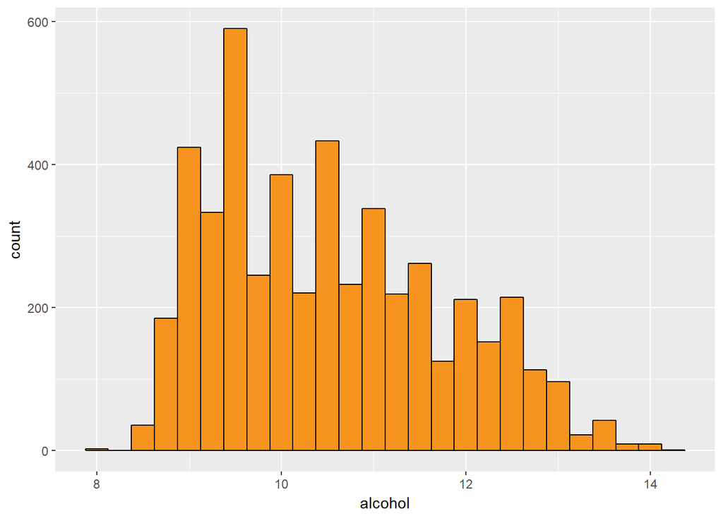

```
##    Min. 1st Qu.  Median    Mean 3rd Qu.    Max.
##    8.00    9.50   10.40   10.51   11.40   14.20
```

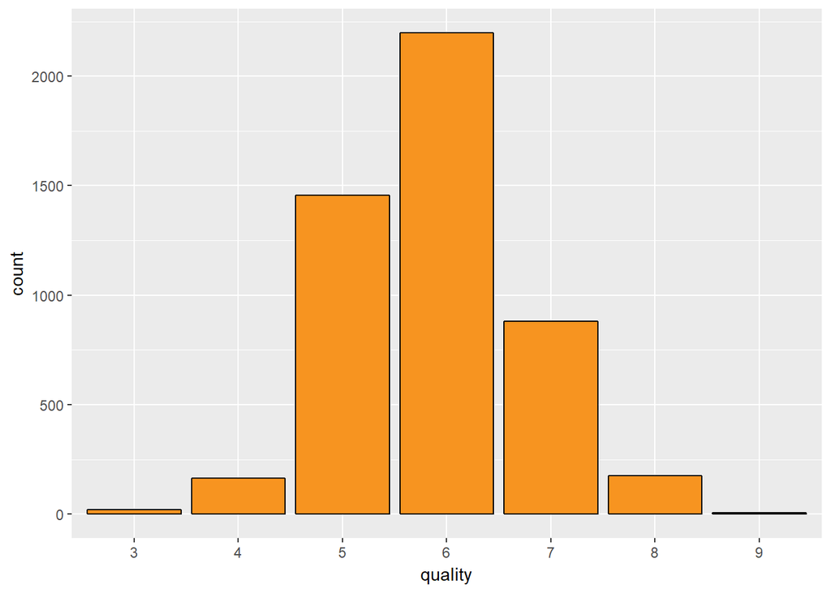

The data in the quality variable is normally distributed with following statistics.

```
##    3    4    5    6    7    8    9
##   20  163 1457 2198  880  175    5
```

Statistics of quality variable show that the majority of white wines fall into 5 and 6 quality categories.

### Bivariate Plots Section and Analysis

From the uni-variant analysis in the above section, reflects some insights of individual attributes in the dataset. In this section, correlations between the attributes were investigated.

In order to understand the relationships between the attributes, following correlation plots matrix was generated. The matrix of plots are advantageous for these type of analysis,because, all the relationships between variables can be easily identified. It is helpful to implement further analysis of the dataset.

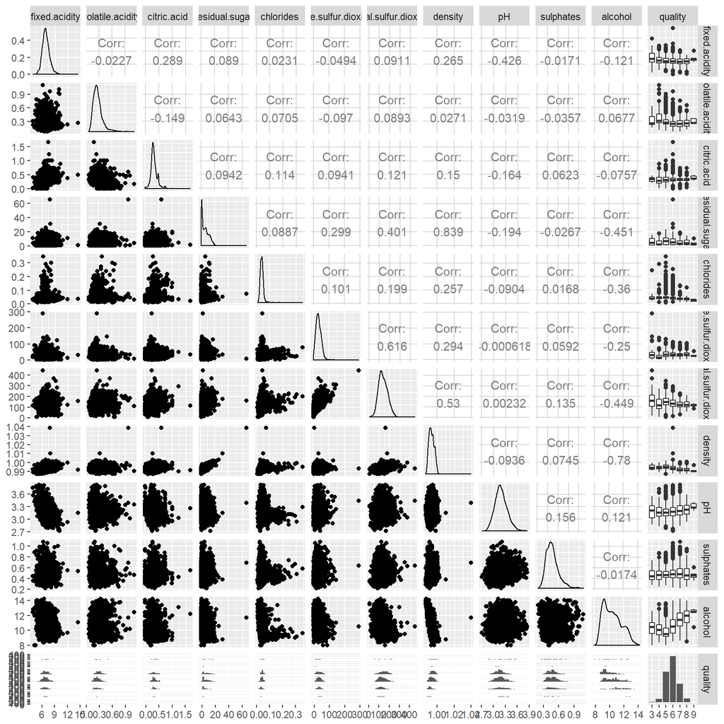

In the above figure, the scatter plots each attributes with the others and the corresponding correlation coefficients are shown.Along the diagonal of the diagram the density plots are displayed for each attribute.

When examine the correlation coefficient for each relationship in above figure, some of the attributes seems to be high to moderately correlated to each other. For example, correlation coefficients of, alcohol vs density, residual sugar vs density, total sulfur dioxide vs density, total sulfur dioxide vs free sulfur dioxide are -0.78, 0.84, 0.53 and 0.62, respectively.

In the below sections, each of those high to moderate relationships were investigated after removing outliers if any.

After preliminary removing density outliers, in alcohol % vs density and density vs total sulfur dioxide relationships, the correlation coefficients are slightly improved (-0.8 and 0.54, respectively). For the other relationships, taking density outliers off, did not improve the correlation (refer multivariate plots below to see the newly calculated correlation coefficients).

Following box plots were generated to further understand the behaviors of high to moderate correlated variables with the wine quality.

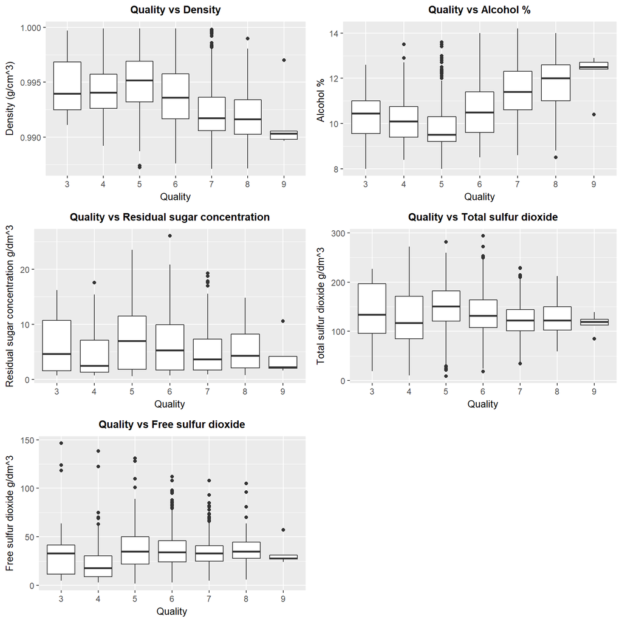

After removing outliers identified in univariate section, data in these box plots indicate still there are more outliers can be present in selected variables (the black color points shows potential outliers). To remove these outliers further understanding the dataset needed.

### Multivariate Plots Section and Analysis

Now its time to check how these relationships (shown in the above bi-variant plots) affect to the wine quality. In the following plots, the attributes are differentiating by the ‘quality’ variable (different color for each quality category).

The quality variable was grouped into 3 main categories as follows in order to see the differences clearly (created a new variable ‘Rank’).

- Quality 1 to 4 = low quality
- Quality 5 to 6 = medium quality
- Quality 7 to 10 = high quality

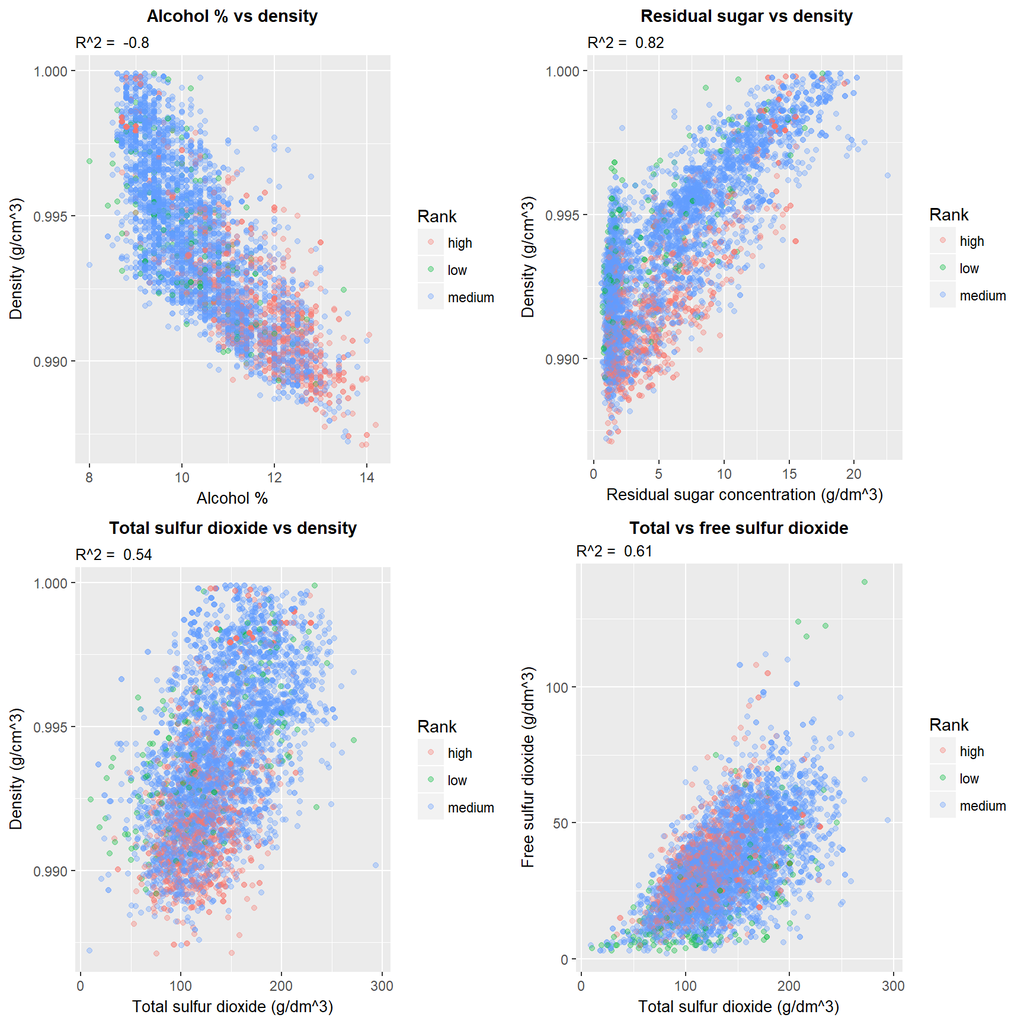

The above four plots show, how the quality (Rank) of wine behave with different attributes.

#### Creating a Multiple linear regression model

During above multivariate analysis, it was noted that density plays major role of determining wine quality with variation of the other parameters such as sugar content, alcohol percentage and sulfur dioxide content. Therefore, multiple regression analysis was carried out to determine a relationship, if any, between density of wines and other three parameters.

The following is the summary of the multiple linear regression model generated. The summary include the correlation coefficient (0.92), y-intercept (1.00), and slopes for each parameter for the model along with other important parameters.

```
##
## Call:
## lm(formula = density ~ total.sulfur.dioxide + residual.sugar +
##     alcohol, data = win_data3)
##
## Residuals:
##        Min         1Q     Median         3Q        Max
## -0.0020412 -0.0005636 -0.0001049  0.0004203  0.0044783
##
## Coefficients:
##                        Estimate Std. Error t value Pr(>|t|)
## (Intercept)           1.004e+00  1.415e-04 7093.16   <2e-16 ***
## total.sulfur.dioxide  5.861e-06  3.184e-07   18.41   <2e-16 ***
## residual.sugar        3.233e-04  2.755e-06  117.36   <2e-16 ***
## alcohol              -1.192e-03  1.101e-05 -108.25   <2e-16 ***
## ---
## Signif. codes:  0 '***' 0.001 '**' 0.01 '*' 0.05 '.' 0.1 ' ' 1
##
## Residual standard error: 0.000792 on 4794 degrees of freedom
## Multiple R-squared:  0.9193, Adjusted R-squared:  0.9192
## F-statistic: 1.819e+04 on 3 and 4794 DF,  p-value: < 2.2e-16
```

In this multiple linear regression model, the correlation coefficient of the density vs other selected parameters improved to 0.92 from the previous maximum individual parameter coefficient of 0.82.

All the p-values for model parameters (y-intercept and slopes) are less than 0.05. Therefore, the model parameters are statistically significant. That indicates the robustness of the model.

#### Validating the model

We can determine the validity of the model by analyzing the following characterization plots and the histograms in the uni-variant section.

The main assumptions for validating a linear model are as follows.

- The variables should be independent from each other.
- The individual variables should be normally distributed.
- The residuals should not show specific patterns.

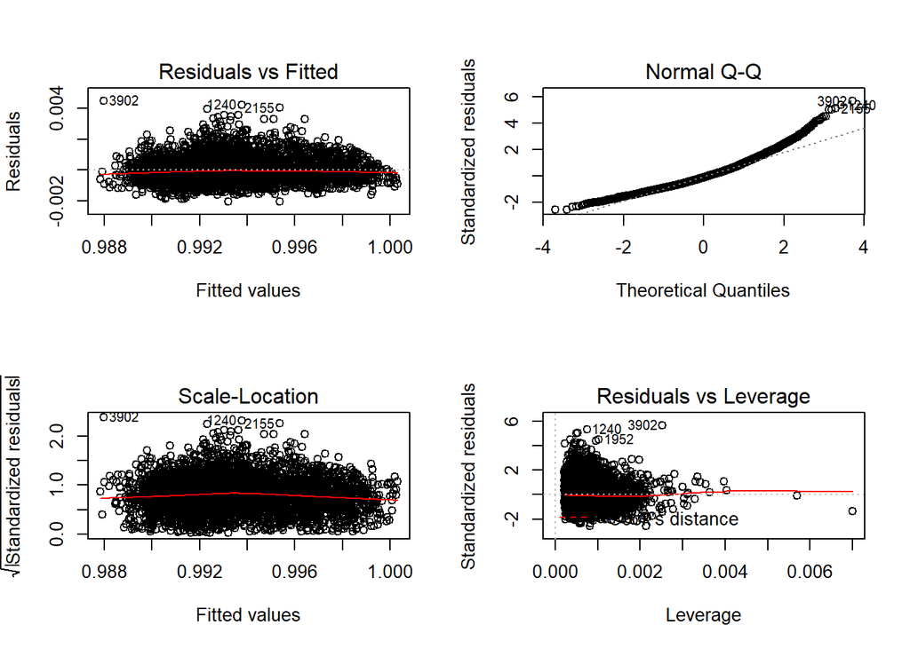

#### Displaying the model with calculated and measured wine density data

The following plot shows the predicted densities using the regression model derived in above section.

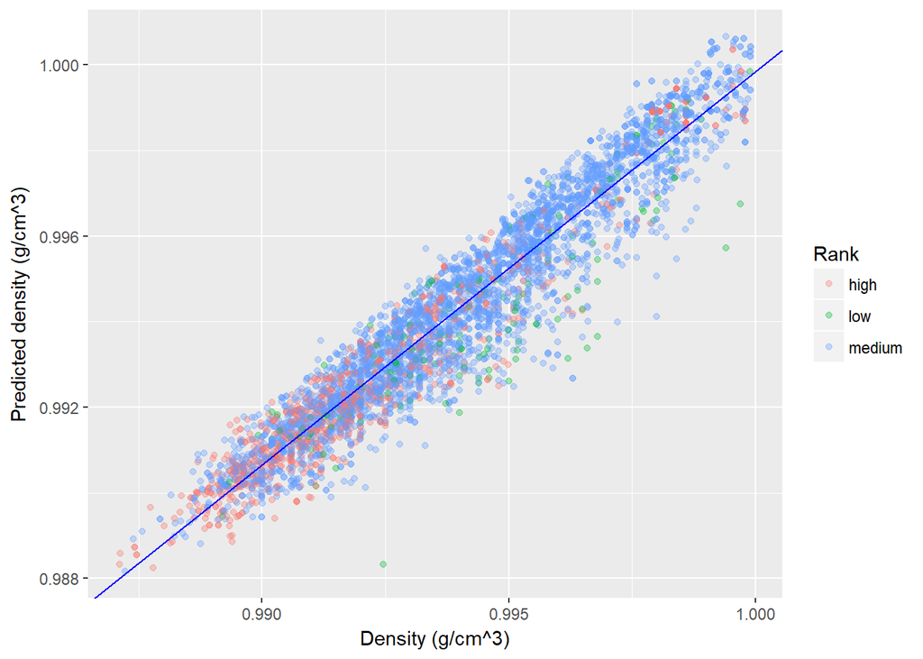

### Final Plots and Summary

In the final plot and summary section, the observations from the above sections are further discussed in detail. For this purpose, I have selected three relationships from the multivariate section. In addition, a multiple linear regression model was developed. The validity of the model also discussed.

#### Behaviours of the quality of wines related to the changes of alcohol % and density

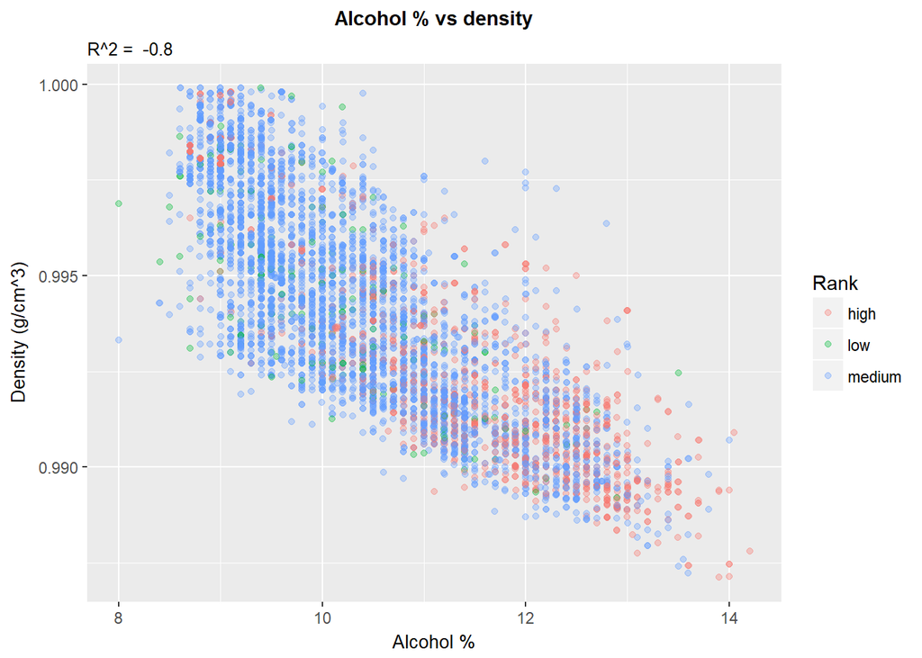

Based on the data in the above plot, the data points corresponding to the high quality (red color points) mainly clustered towards the bottom right side of the plot. This behavior indicates the quality of wine is generally high when the alcohol percentage is high and density is low with a few exceptions.

#### Behaviours of the quality of wines related to the changes of residual sugar concentration and density

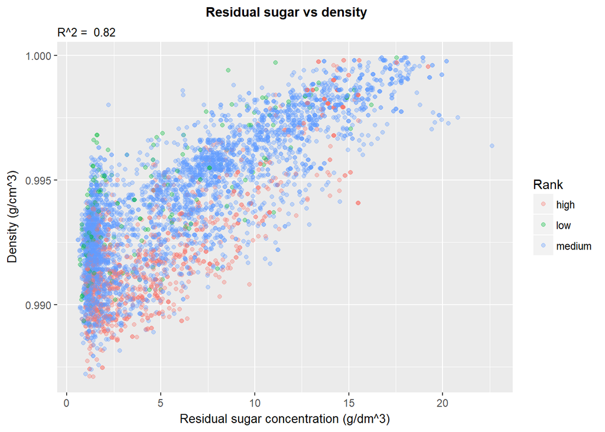

In above plot, there is slight separation of high quality wines with the other qualities. That arrangement of high quality data points suggest that in general the quality of a wine type is high when the density and the residual sugar concentrations are low with some exceptions.

#### Behaviours of the quality of wines related to the changes of density

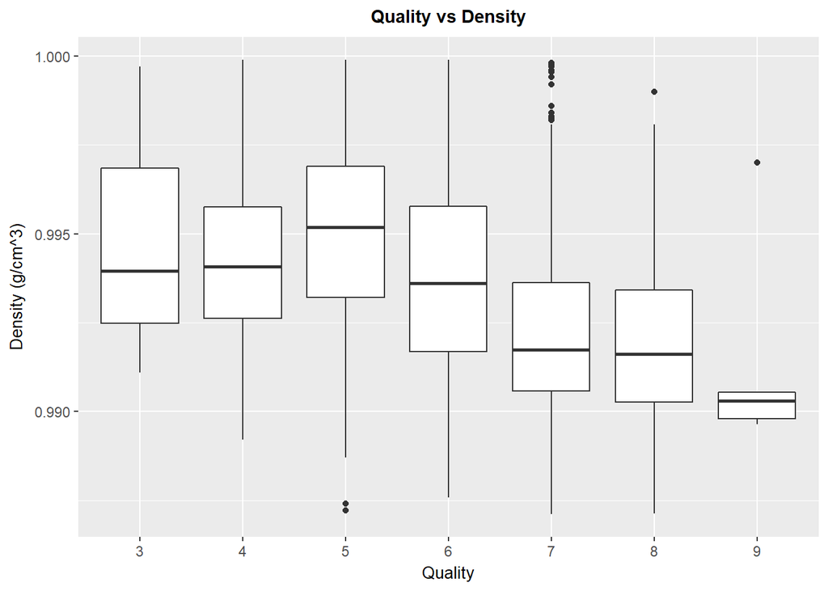

In the above plot (Quality vs Density), the median values of density of each quality category, seemed to have a trend. That is when the density is low, the quality of wine is high in general. This behavior further support with the observations and validate the multiple linear regression model generated in multivariate section.

### Reflection

A data set related to white wine quality was investigated and analysed. By definition, some of the variables have similar characteristics and relation. For example, pH and citric acid concentration should be related each other, because, literally those variable reflects same information. However, when determining the relationships of the variables each other (see the bi-variant matrix of plots) pH and citric acid concentration do not show a good relationship as expected (R^2 = -0.16).

Density of seems to have better correlation between sugar, alcohol and sulfur dioxide content. Based on the these relationships, using density and other mentioned variables, a multiple linear regression model was generated. This generated model can be used to determine the wine quality.

One of the difficulty of this dataset that someone can face into is lack of technical background of chemical and physical properties of substances. Because, variables are in this dataset is highly technical. Fortunately, I had the required technical background. Therefore, I was able to quickly identify the discrepancies in the data in some variables. For example, the density values of wine cannot possibly exceed 1.00 g/cm^3 due to the contents/ingredients in the wine solutions (liquid). These type of errors of data cannot identify without a knowledge of specific technical limitation of the data. In this case I was able to successfully identify and eliminate the errors of some data.

Since there are Some discrepancies in some data, the validity and quality of the data should be examined before doing further analysis with the dataset.

As a future work, the model proposed above should be improved to get accurate predictions.Other classification techniques such that techniques in The machine-leaning methods can be used to improve this model or define a separate more accurate model.